# re2_getting creative with ozone concentration

# Limitations- Despite its value, the dataset presents limitations. Observations span diverse sites with distinct characteristics—urban, natural, and insular—each with its own microclimate. Moreover, data were collected at varying times, introducing spatial and temporal heterogeneity that may confound results. These inconsistencies highlight the need for standardized, temporally and spatially aligned data collection. Nonetheless, this analysis provides a foundation for further exploration of seasonal and anthropogenic impacts on air quality.

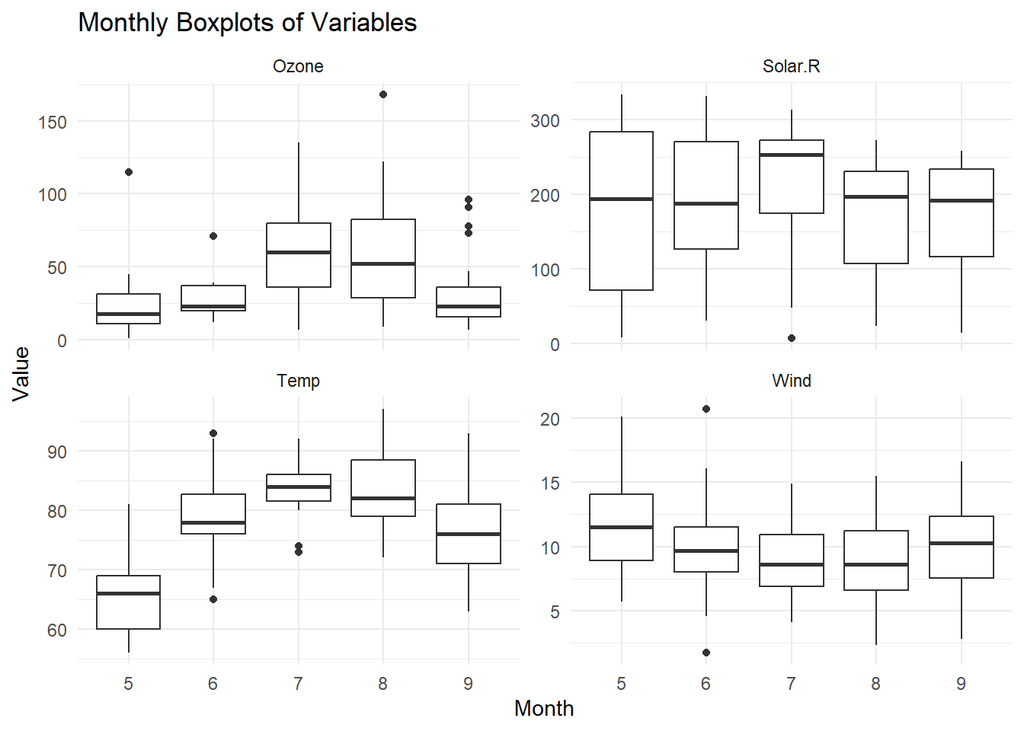

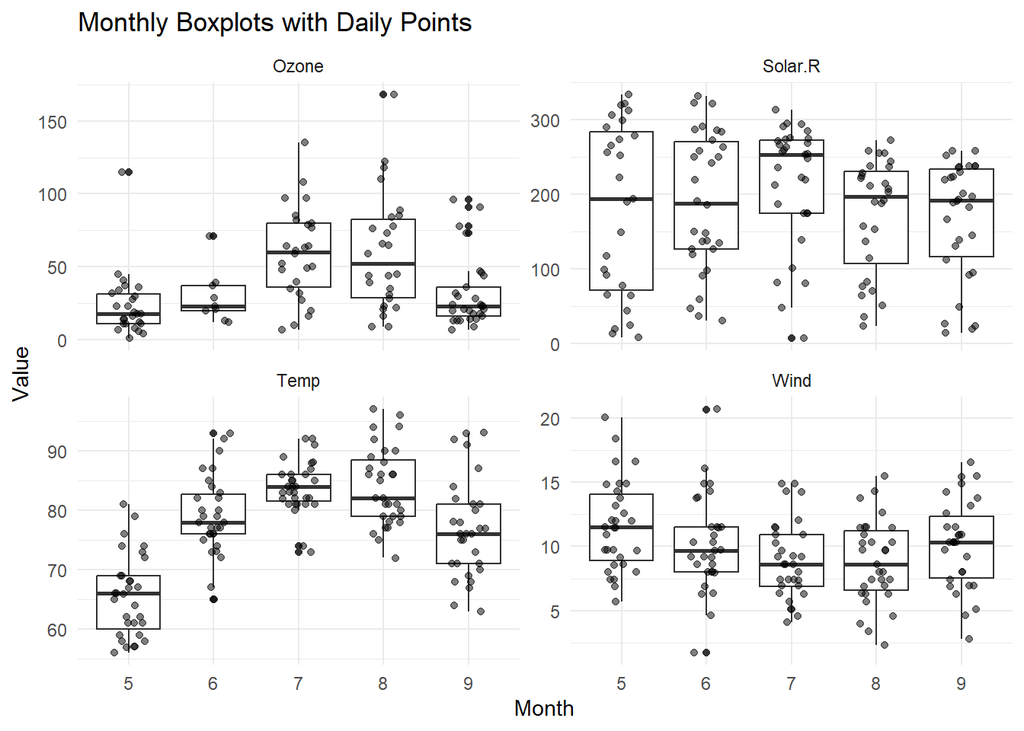

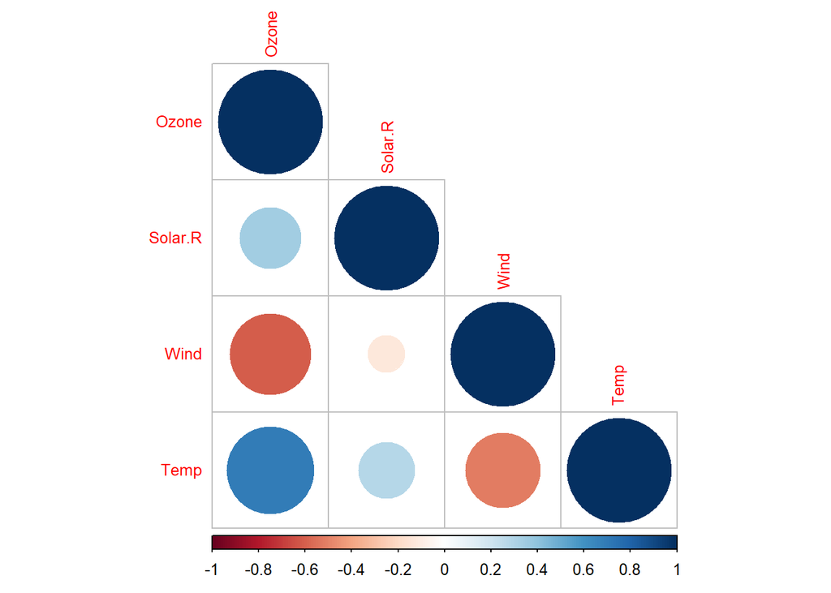

[output not shown]

[output cut: 519 more lines]

[output not shown]

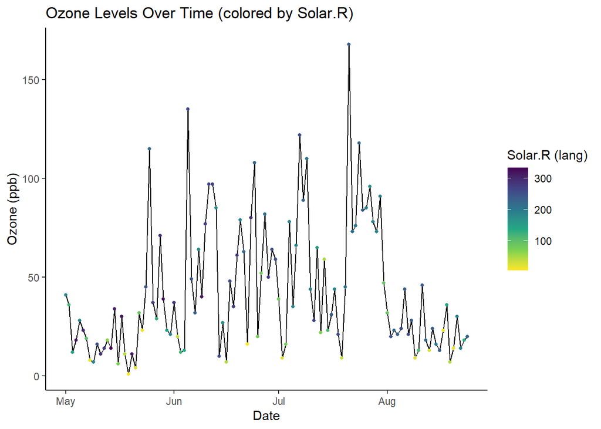

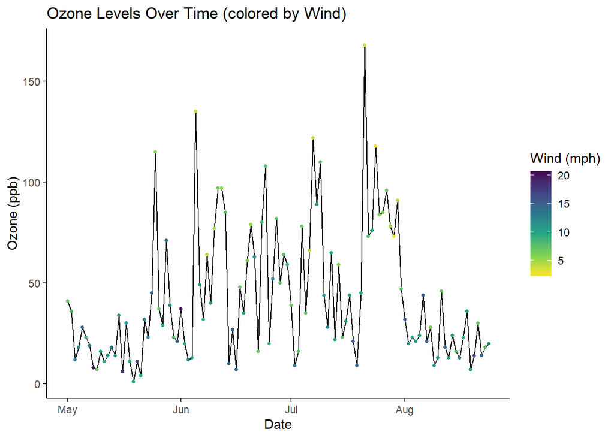

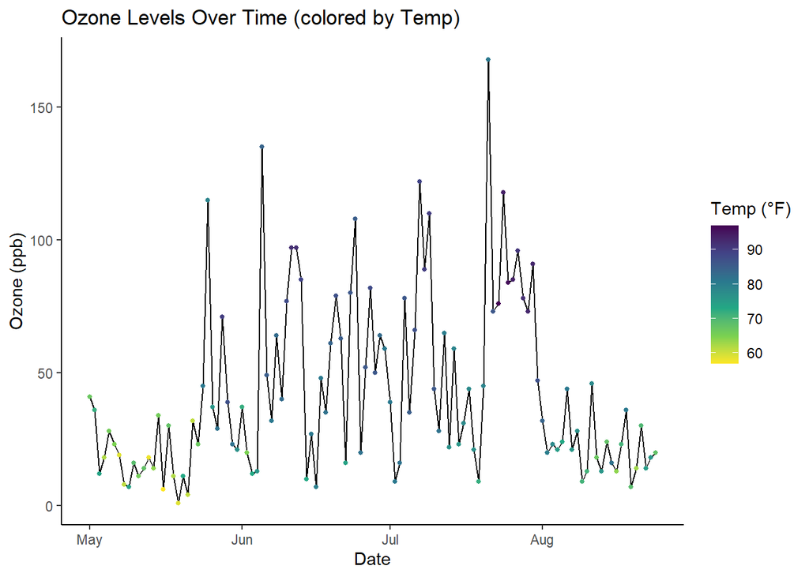

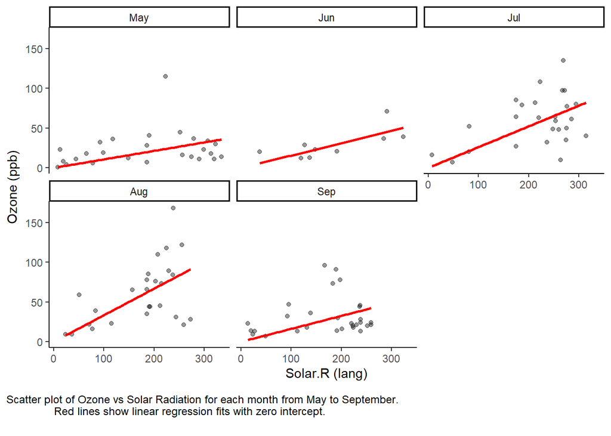

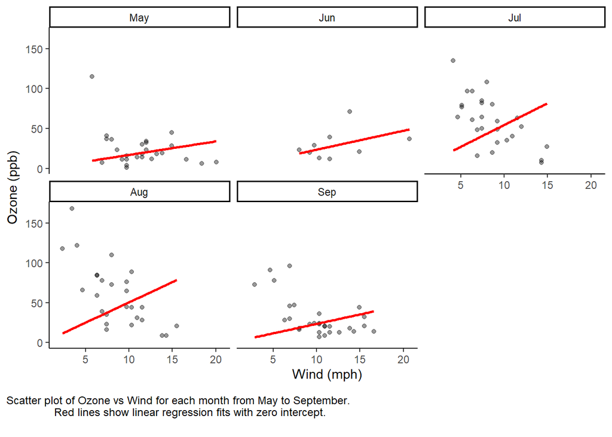

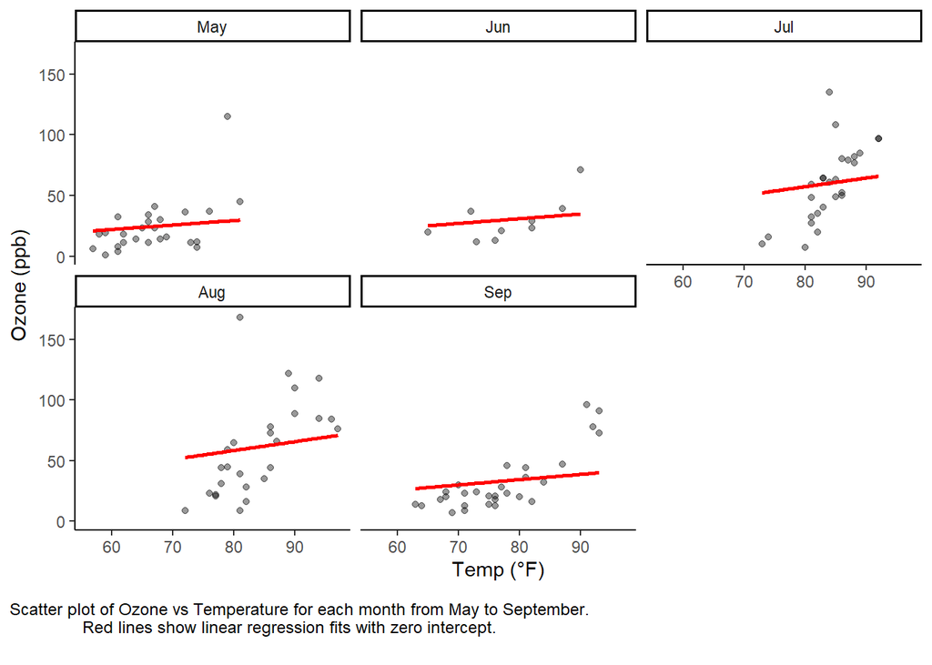